# STAT 240 Discussion 6

## Group 344:6 (use the assigned group name/number)

## Members Present

- Lacey Dinh; Rahul Konchada
- **Lacey Dinh**

## Members Absent

- TJ Armasanaa

## Questions

### 1

For each scenario, explain why the random variable does *not* have a binomial distribution.

1. A bucket contains 10 colored tokens with five that are red and five that are blue. Four tokens are drawn at random from the bucket one at a time, but without replacing the tokens drawn. $X_1$ is the number of red tokens selected.
- Since the tokens are drawn without replacement, the probability of selecting a red token changes for each subsequent draw. The probability of selecting a red token on the first draw is $5/10$ or $1/2$, but on the second draw, the probability of selecting a red token is $4/9$, and similarly for the probability of selecting on the third draw and on the fourth draw. Therefore, the number of red tokens selected is not independent and identically distributed, which is a key assumption of the binomial distribution. In other words, the probability of success (selecting a red token) changes for each draw and is not constant. Consequently, $X_1$ does not have a binomial distribution.
2. A fair coin is tossed repeatedly until the tenth head is tossed. $X_2$ is the number of tails tossed prior to the tenth head.
- We have a variable that represents the number of tails tossed prior to the tenth head. Here, the number of trials (i.e., coin tosses) required to achieve $10$ heads is not fixed and is not independent of the outcome. The number of tails tossed prior to the tenth head depends on how many tails were tossed before the tenth head was achieved, which is a random variable. Therefore, $X_2$ does not have a binomial distribution.
3. Four buckets each contain a total of five tokens each, some red and some blue. The number of red tokens in the buckets are 1, 2, 3, and 4 with blue tokens making up the remainder. One token is drawn at random from each bucket. $X_3$ is the total number of red tokens drawn.
- Each trial (i.e., each token draw) is not independent of the others, since the number of red tokens in each bucket is different. Specifically, the probability of drawing a red token in each bucket is different. For example, in the first bucket, the probability of drawing a red token is $1/5$, whereas in the fourth bucket, the probability of drawing a red token is $4/5$. Since the probabilities of success are not the same for each trial, the conditions for a binomial distribution are not met. Therefore, $X_3$ does not have a binomial distribution.

### 2

Let $X \sim \operatorname{Binomial}(25,0.4)$.

#### A

Calculate and report the mean $\mu=\mathrm{E}(X)$ and the standad deviation $\sigma=\sqrt{\operatorname{Var}(X)}$

```r
n = 25
p = 0.4
mu = n*p
mu
```

```
## [1] 10
```

```r
sigma = sqrt(n * p * (1 - p))
sigma
```

```
## [1] 2.44949
```

> The mean is 10; and the Standard deviation is 2.44949.

#### B

Calculate $\text{P}(X \geq 14)$

```r
n <- 25 # number of trials
p <- 0.4 # probability of success

# Calculate P(X >= 14)
1 - pbinom(13, n, p)
```

```
## [1] 0.07780106
```

> Therefore, the probability of getting 14 or more successes in 25 trials with a probability of success of 0.4 is approximately 0.0778.

#### C

Create a graph of the $\operatorname{Binomial}(25,0.4)$ distribution. Color the segments for $x=14,15,...,25$ red and use gray for the rest. Plot using `theme_minimal()`.

You may edit the code in this block which does something similar for a different problem. Note the use of `geom_binom_density()` with different values of `a` AND `b`.

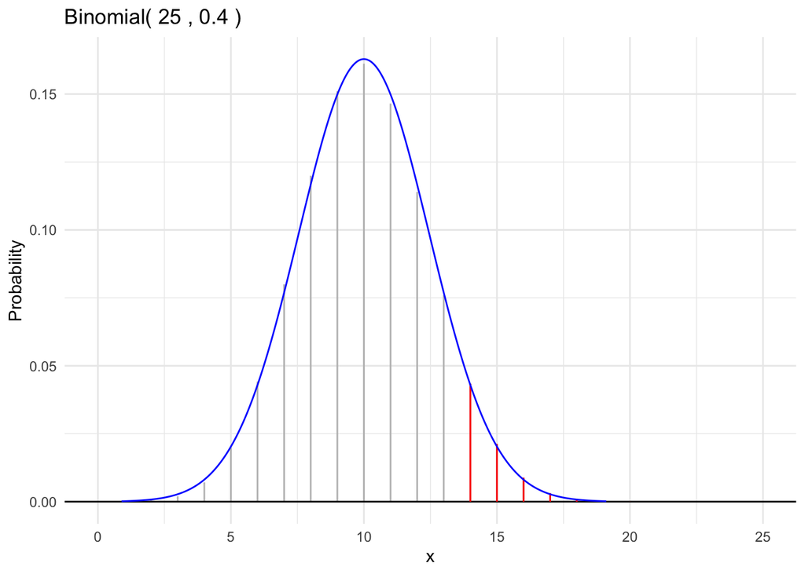

```r
#gbinom(100, 0.5, a = 30, b = 70) +
  #geom_binom_density(100, 0.5, a = 35, b = 50, color = "gray") +
  #geom_binom_density(100, 0.5, a = 55, b = 70, color = "red") +
  #theme_minimal()
gbinom(25, 0.4, color = 'gray', scale = TRUE) +
  geom_binom_density(25, 0.4, a = 14, b = 25, color = "red") +
  geom_norm_density(mu, sigma)+
  theme_minimal()
```

### 3

Create a data frame with columns `n`, `p`, `x`, `mu`, and `prob` where:

- `n` varies from 2 to 100 by twos (so each `n` value is even);
- `p` equals 0.5;
- `x` is $n/2$;
- `mu` is the mean of the distribution;
- `prob` is $P(X = x)$

Show the first few rows using `head()`.

```r
# Create a dataframe with n, p, x, mu, and prob columns
df <- tibble(n = seq(from = 2, to = 100, by = 2),
                 p = 0.5,
               #rep(0.5, 50),
                 x = n/2,
               #seq(from = 1, to = 50),
                 mu = n *p,
               #rep(seq(from = 1, to = 25, by = 0.5), 2)[1:50],
                 prob = dbinom( x, size = n, prob = p))
             #(seq(from = 1, to = 50), size = seq(from = 2, to = 100, by = 2), prob = 0.5))

# Show the first few rows
head(df, n = 10)
```

```
## # A tibble: 10 × 5
##        n     p     x    mu  prob
##    <dbl> <dbl> <dbl> <dbl> <dbl>
##  1     2   0.5     1     1 0.5
##  2     4   0.5     2     2 0.375
##  3     6   0.5     3     3 0.312
##  4     8   0.5     4     4 0.273
##  5    10   0.5     5     5 0.246
##  6    12   0.5     6     6 0.226
##  7    14   0.5     7     7 0.209
##  8    16   0.5     8     8 0.196
##  9    18   0.5     9     9 0.185
## 10    20   0.5    10    10 0.176
```

**(a)** What is the relationship between `x` and `mu`? >The value of x is half of the value of n, so x = n/2. The value of mu is also equal to x since the mean of a binomial distribution with probability of success p = 0.5 and sample size n is equal to n/2.

**(b)** Make a line graph of `prob` versus `n`.

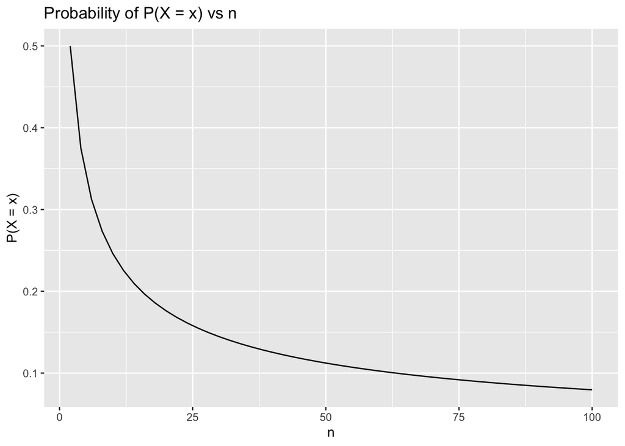

```r
# Plot the graph
ggplot(df, aes(x = n, y = prob)) +
  geom_line() +
  xlab("n") +
  ylab("P(X = x)") +
  ggtitle("Probability of P(X = x) vs n")
```

**(c)** Describe the pattern: how does the probability that a random variable is equal to the mean (when the mean is a possible value) change as $n$ increases? - As `n` increases, the probability that a random variable is equal to the mean (when the mean is a possible value) decreases. This can be observed from the graph as the curve becomes flatter and the probability values decrease towards $0$. This is because as the sample size increases, the distribution becomes more spread out and the probability of getting a specific value decreases.

### 4

The central limit theorem implies that the binomial distribution converges to a normal distribution as $n$ increases. This problem will examine one aspect of the convergence, namely the right tail probability of being more than two standard deviations above the mean, $P(X > \mu + 2\sigma)$.

**(a)** What is the probability that a normal random variable with mean $\mu$ and standard deviation $\sigma$ exceeds $\mu + 2 \sigma$? Display answer rounded to four decimal places.

```r
mu = 0
sigma = 1
pnorm(mu + 2*sigma, mean = mu, sd = sigma, lower.tail = FALSE)
```

```
## [1] 0.02275013
```

- $P(X > \mu + 2\sigma)$ = $𝑃(𝑍 > 2)$ = $0.0228$ (rounded to four decimal places), where Z is the standard normal random variable and the approximation follows from the standard normal table.

**(b)**

Create a data frame with columns `n`, `p`, `mu`, `sigma`, `x`, and `prob` where:  
- `n` varies from 1 to 1000 by ones;  
- `p` equals 0.5;  
- `mu` is the mean of the distribution;  
- `sigma` is the standard deviation of the distribution;  
- `x` equals `mu` + 2*`sigma`;  
- `prob` is $P(X > x)$

Display the first few rows of the data frame with `head()`.

```r
q4b_df = tibble(n = 1:1000)%>%
             mutate(p = 0.5,
                    mu = n*p,
                    sigma = sqrt(n * p*(1 - p)),
                    x = mu + 2 *sigma,
                    prob = 1 - pnorm(floor(x), mean = mu, sd = sigma))

head(q4b_df, n = 10)
```

```
## # A tibble: 10 × 6
##        n     p    mu sigma     x   prob
##    <int> <dbl> <dbl> <dbl> <dbl>  <dbl>
##  1     1   0.5   0.5 0.5    1.5  0.159
##  2     2   0.5   1   0.707  2.41 0.0786
##  3     3   0.5   1.5 0.866  3.23 0.0416
##  4     4   0.5   2   1      4    0.0228
##  5     5   0.5   2.5 1.12   4.74 0.0899
##  6     6   0.5   3   1.22   5.45 0.0512
##  7     7   0.5   3.5 1.32   6.15 0.0294
##  8     8   0.5   4   1.41   6.83 0.0786
##  9     9   0.5   4.5 1.5    7.5  0.0478
## 10    10   0.5   5   1.58   8.16 0.0289
```

**(c)** Plot the right tail probabilities versus $n$. Add a red, dashed, horizontal line at the value you found in part **(a)**. Add a smooth curve which lessens the visual impact of the oscillations due to the discreteness of the binomial distribution.

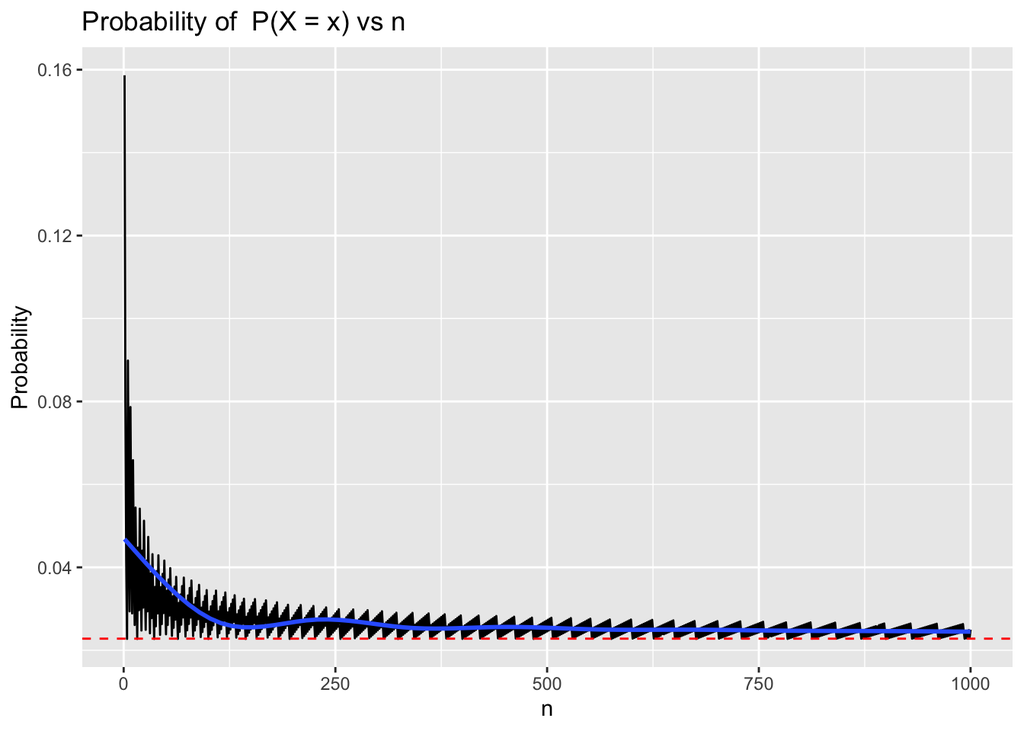

```r
ggplot(q4b_df , aes(x = n, y = prob)) +
  geom_line() +
  geom_smooth(se = FALSE)+
  geom_hline(yintercept = 0.0228, linetype = "dashed", color = "red") +
  xlab("n") +
  ylab("Probability") +
  ggtitle("Probability of  P(X = x) vs n")
```

**(d)** Repeat parts **(b)** and **(c)** if $p = 0.005$.

```r
q4d_df = tibble(n = 1:1000)%>%
             mutate(p = 0.005,
                    mu = n*p,
                    sigma = sqrt(n * p*(1 - p)),
                    x = mu + 2 *sigma,
                    prob = 1 - pnorm(floor(x), mean = mu, sd = sigma))

head(q4d_df, n = 10)
```

```
## # A tibble: 10 × 6
##        n     p    mu  sigma     x  prob
##    <int> <dbl> <dbl>  <dbl> <dbl> <dbl>
##  1     1 0.005 0.005 0.0705 0.146 0.528
##  2     2 0.005 0.01  0.0997 0.209 0.540
##  3     3 0.005 0.015 0.122  0.259 0.549
##  4     4 0.005 0.02  0.141  0.302 0.556
##  5     5 0.005 0.025 0.158  0.340 0.563
##  6     6 0.005 0.03  0.173  0.376 0.569
##  7     7 0.005 0.035 0.187  0.408 0.574
##  8     8 0.005 0.04  0.199  0.439 0.579
##  9     9 0.005 0.045 0.212  0.468 0.584
## 10    10 0.005 0.05  0.223  0.496 0.589
```

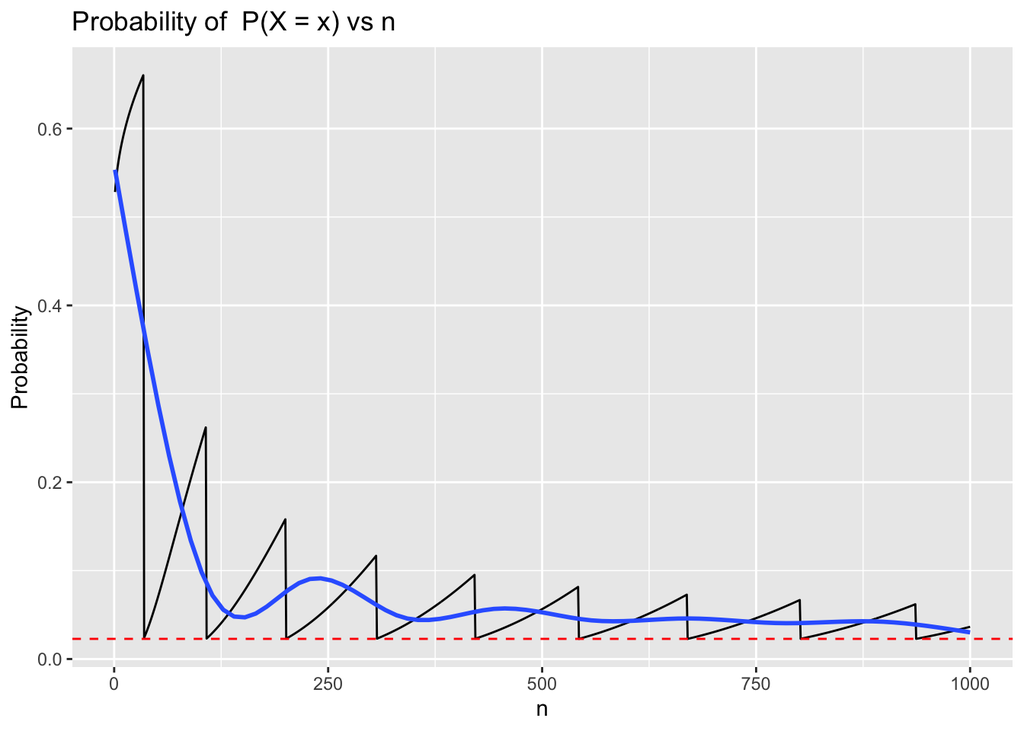

```r
ggplot(q4d_df, aes(x = n, y = prob)) +
  geom_line()+
  geom_smooth(se = FALSE)+
  geom_hline(yintercept = 0.0228, linetype = "dashed", color = "red") +
  xlab("n") +
  ylab("Probability") +
  ggtitle("Probability of  P(X = x) vs n")
```

**(e)**

### 5

Repeat problems 4B and 4C if $p=0.005$

### 6

Draw graphs of the binomial distributions for $n=500$ and $p = 0.5$ and $p = 0.005$, scaled so that the x axis is restricted to where the probabilities are relatively large. (One graph for each of the two $p$’s.) Overlay each plot with a red normal density with a mean and standard deviation that matches the mean and standard deviation of the corresponding binomial distribution. (Use functions in *gprob.R* for these graphs and set `scale=TRUE`.)

Compare the skewness of the distributions. Comment on how this might help explain the differences in the right tail probabilities from Problem 3.

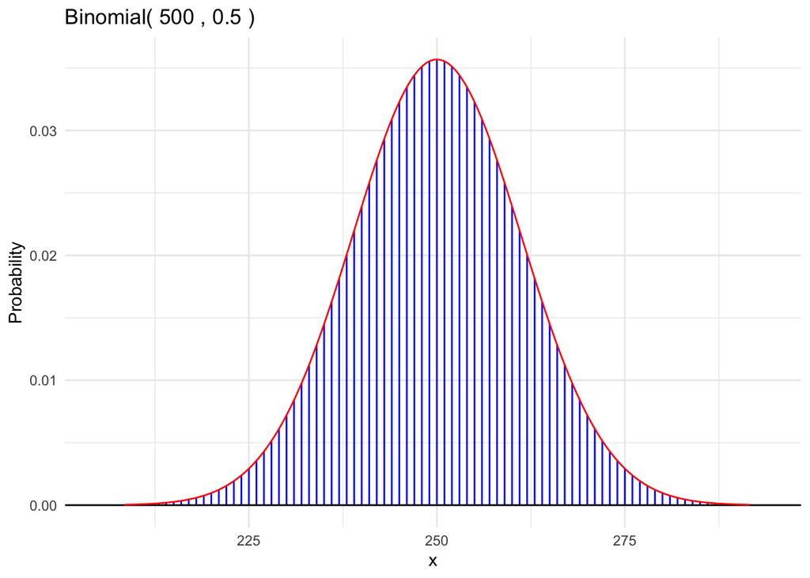

```r
# Plot for p=0.5
n = 500
p = 0.5
mu <- n * p
sigma = sqrt(n*p*(1-p))

gbinom(n, p, scale=TRUE) +
  geom_norm_density(mu, sigma, color = "red") +
  theme_minimal()
```

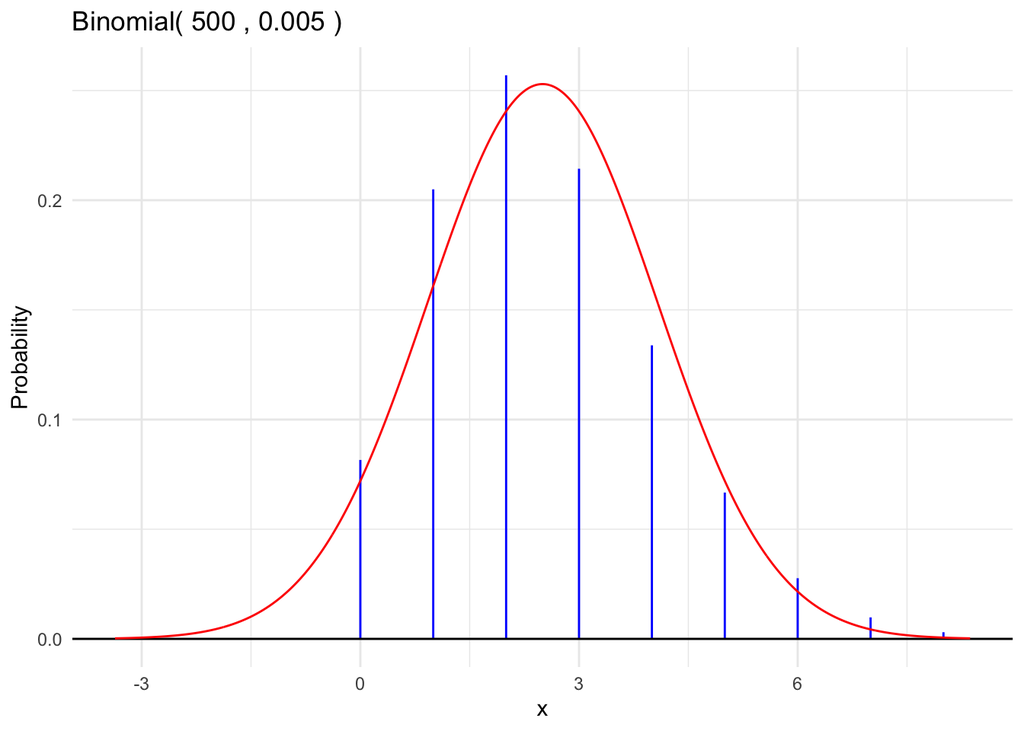

```r
# Plot for p=0.005
n = 500
p = 0.005
mu <- n * p
sigma = sqrt(n*p*(1-p))

gbinom(n, p, scale=TRUE) +
  geom_norm_density(mu, sigma, color = "red") +
  theme_minimal()
```